# An Introduction to Pandas

- Adapted from the original from Chapter 2 of *Learning IPython for Interactive Computing and Data Visualization*, 2nd ed., by Cyrille Rossant, Packt Publishing, 2015.
- With material from *Python for Data Analysis* by Wes McKinney, O'Reilly, 2013.

> Panos Louridas, Associate Professor  
> Department of Management Science and Technology  
> Athens University of Economics and Business  
> louridas@aueb.gr

# Setting the Scene

- We start by importing a few of the packages we'll need.
- Most data analytics in Python is performed using the following packages:
  - [NumPy](http://www.numpy.org/)
  - [pandas](http://pandas.pydata.org/)
  - [matplotlib](http://matplotlib.org/)
- To perform the analysis, we will be using [Jupyter](http://jupyter.org/).
- If you are using the Anaconda distribution, these packages are already included.
- If you are using standard Python, you can install them with:
  - `pip install numpy`
  - `pip install pandas`
  - `pip install matplotlib`
  - `pip install jupyter`
- Note that if you have both version 2 and version 3 of Python installed you may need to use `pip3`.

```python
import numpy as np

import pandas as pd
import matplotlib.pyplot as plt

%matplotlib inline
```

- The last line is only required for Jupyter notebooks, not for direct Python use.

# Obtaining the Data

```python
data_filename = 'data/nyc_data.csv'
fare_filename = 'data/nyc_fare.csv'
```

- Let's have a look at the form of the data.

```
medallion,hack_license,vendor_id,rate_code,store_and_fwd_flag,pickup_datetime,dropoff_datetime,passenger_count,trip_time_in_secs,trip_distance,pickup_longitude,pickup_latitude,dropoff_longitude,dropoff_latitude
76942C3205E17D7E7FE5A9F709D16434,25BA06A87905667AA1FE5990E33F0E2E,VTS,1,,2013-01-01 00:00:00,2013-01-01 00:05:00,3,300,0.61,-73.955925,40.781887,-73.963181,40.777832000000004
517C6B330DBB3F055D007B07512628B3,2C19FBEE1A6E05612EFE4C958C14BC7F,VTS,1,,2013-01-01 00:05:00,2013-01-01 00:21:00,1,960,3.28,-74.005501,40.745734999999996,-73.964943,40.755722
ED15611F168E41B33619C83D900FE266,754AEBD7C80DA17BA1D81D89FB6F4D1D,CMT,1,N,2013-01-01 00:05:52,2013-01-01 00:12:18,1,386,1.5,-73.969955,40.79977,-73.954567,40.787392
B33E704CC189E80C9671230C16527BBC,6789C77E1CBDC850C450D72204702976,VTS,1,,2013-01-01 00:06:00,2013-01-01 00:06:00,6,0,0.0,-73.99143199999999,40.755081,-73.991417,40.755085
```

- The data is in the CSV format (comma separated values).
- A files comprises records, one per row.
- In each row, each field of the record is separated by comma (or some other delimiter) from the next field.
- In this way we can think of rows composed of columns.
- The first row may contain the names of the columnns, in which case it is a header.
- Parsing a CSV file without an appropriate library is complicated because there are rules for escaping commas when they are inside a column, etc.

# Reading the Data

- We'll use the `read_csv()` function provided by Pandas.

```python
data = pd.read_csv(data_filename,
                   parse_dates=['pickup_datetime','dropoff_datetime'])

fare = pd.read_csv(fare_filename,
                   parse_dates=['pickup_datetime'])
```

# Dataframes

- The `data` and `fare` variables are `DataFrame` objects.
- A `DataFrame` is a table containing rows (observations or samples) and columns (features or variables).
- DataFrames can contain text, numbers, dates, and other types of data.
- The `head()` method shows the first lines of a DataFrame.

```python
data.head(3)
```

|  | medallion | hack_license | vendor_id | rate_code | store_and_fwd_flag | pickup_datetime | dropoff_datetime | passenger_count | trip_time_in_secs | trip_distance | pickup_longitude | pickup_latitude | dropoff_longitude | dropoff_latitude |
| --- | --- | --- | --- | --- | --- | --- | --- | --- | --- | --- | --- | --- | --- | --- |
| 0 | 76942C3205E17D7E7FE5A9F709D16434 | 25BA06A87905667AA1FE5990E33F0E2E | VTS | 1 | NaN | 2013-01-01 00:00:00 | 2013-01-01 00:05:00 | 3 | 300 | 0.61 | -73.955925 | 40.781887 | -73.963181 | 40.777832 |
| 1 | 517C6B330DBB3F055D007B07512628B3 | 2C19FBEE1A6E05612EFE4C958C14BC7F | VTS | 1 | NaN | 2013-01-01 00:05:00 | 2013-01-01 00:21:00 | 1 | 960 | 3.28 | -74.005501 | 40.745735 | -73.964943 | 40.755722 |
| 2 | ED15611F168E41B33619C83D900FE266 | 754AEBD7C80DA17BA1D81D89FB6F4D1D | CMT | 1 | N | 2013-01-01 00:05:52 | 2013-01-01 00:12:18 | 1 | 386 | 1.50 | -73.969955 | 40.799770 | -73.954567 | 40.787392 |

- Similarly, the `tail()` method shows the last lines of a DataFrame.

```python
data.tail(3)
```

|  | medallion | hack_license | vendor_id | rate_code | store_and_fwd_flag | pickup_datetime | dropoff_datetime | passenger_count | trip_time_in_secs | trip_distance | pickup_longitude | pickup_latitude | dropoff_longitude | dropoff_latitude |
| --- | --- | --- | --- | --- | --- | --- | --- | --- | --- | --- | --- | --- | --- | --- |
| 846942 | D87EB3AD2ED303B3D92E37D871B2C2E9 | F578F0435B49B3D7B9A7AAFC663A82CD | VTS | 1 | NaN | 2013-12-31 23:59:00 | 2014-01-01 00:05:00 | 1 | 360 | 2.23 | -73.993492 | 40.729347 | -74.013725 | 40.702332 |
| 846943 | F74743D90F84644B1FA4576F4A82A8A3 | 537121DB04EC62BADFA44D8F03755A64 | VTS | 1 | NaN | 2013-12-31 23:59:00 | 2014-01-01 00:08:00 | 1 | 540 | 1.76 | -73.978477 | 40.772945 | -73.963814 | 40.773922 |
| 846944 | E5DCEBA68A6094576B10AFC609C61E29 | 735F78FA4CB06B5CB7122FF31822F68E | CMT | 1 | N | 2013-12-31 23:59:24 | 2014-01-01 00:22:26 | 1 | 1381 | 4.50 | -73.987206 | 40.750568 | -73.970909 | 40.795815 |

- The `describe()` method shows basic statistics of all columns, as shown below.

```python
data.describe()
```

|  | rate_code | passenger_count | trip_time_in_secs | trip_distance | pickup_longitude | pickup_latitude | dropoff_longitude | dropoff_latitude |
| --- | --- | --- | --- | --- | --- | --- | --- | --- |
| count | 846945.000000 | 846945.000000 | 8.469450e+05 | 8.469450e+05 | 846945.000000 | 846945.000000 | 846945.000000 | 846945.000000 |
| mean | 1.026123 | 1.710272 | 8.125239e+02 | 9.958211e+00 | -73.975155 | 40.750490 | -73.974197 | 40.750967 |
| std | 0.223480 | 1.375266 | 1.609831e+04 | 6.525205e+03 | 0.035142 | 0.027224 | 0.033453 | 0.030766 |
| min | 0.000000 | 0.000000 | -1.000000e+01 | 0.000000e+00 | -74.098305 | 40.009911 | -74.099998 | 40.009911 |
| 25% | 1.000000 | 1.000000 | 3.610000e+02 | 1.050000e+00 | -73.992371 | 40.736031 | -73.991570 | 40.735207 |
| 50% | 1.000000 | 1.000000 | 6.000000e+02 | 1.800000e+00 | -73.982094 | 40.752975 | -73.980614 | 40.753597 |
| 75% | 1.000000 | 2.000000 | 9.600000e+02 | 3.200000e+00 | -73.968048 | 40.767460 | -73.965157 | 40.768227 |
| max | 6.000000 | 6.000000 | 4.294796e+06 | 6.005123e+06 | -73.028473 | 40.996132 | -73.027061 | 40.998592 |

# Making Plots with matplotlib

- Visualizing *raw* data, as opposed to aggregated statistics, often allows us to get a general idea about a data set.
- Here, we will display the pickup and dropoff locations of all trips.
- The first step is to get the actual coordinates from the DataFrame.
- Let's start by checking the columns of the data.

```python
data.columns
```

```
Index(['medallion', 'hack_license', 'vendor_id', 'rate_code',
       'store_and_fwd_flag', 'pickup_datetime', 'dropoff_datetime',
       'passenger_count', 'trip_time_in_secs', 'trip_distance',
       'pickup_longitude', 'pickup_latitude', 'dropoff_longitude',
       'dropoff_latitude'],
      dtype='object')
```

- Four columns represent latitude and longitude.
- To save typing we'll refer to them by four variables.

```python
p_lng = data.pickup_longitude
p_lat = data.pickup_latitude
d_lng = data.dropoff_longitude
d_lat = data.dropoff_latitude
```

- With pandas, every column of a `DataFrame` can be obtained with the `mydataframe.columnname` syntax.
- An alternative syntax is `mydataframe['columnname']`, so the above is the same as:

```
p_lng = data['pickup_longitude']
p_lat = data['pickup_latitude']
d_lng = data['dropoff_longitude']
d_lat = data['dropoff_latitude']
```

- The dot notation allows us to use tab for autocompleting column names.
- Here, we created four variables with the coordinates of the pickup and dropoff locations.
- These variables are all `Series` objects.
- We can check some of the longitudes.

```python
 p_lng[:10]
```

```
0   -73.955925
1   -74.005501
2   -73.969955
3   -73.991432
4   -73.966225
5   -73.955238
6   -73.985580
7   -73.999413
8   -73.992180
9   -74.006554
Name: pickup_longitude, dtype: float64
```

- A `Series` is an indexed list of values.
- Therefore, a `DataFrame` is simply a collection of `Series` columns.
- Before we can make a plot, we need to get the coordinates of points in pixels instead of geographical coordinates.
- We can use the following function that performs a Mercator projection.

```python
 def lat_lng_to_pixels(lat, lng):
    lat_rad = lat * np.pi / 180.0
    lat_rad = np.log(np.tan((lat_rad + np.pi / 2.0) / 2.0))
    x = 100 * (lng + 180.0) / 360.0
    y = 100 * (lat_rad - np.pi) / (2.0 * np.pi)
    return (x, y)
```

- NumPy implements many mathematical functions like `np.log()` and `np.tan()`.
- These functions work on scalar numbers and also on pandas objects such as `Series`.
- The following function call returns two new `Series` px and py.

```python
px, py = lat_lng_to_pixels(p_lat, p_lng)
px.head(10)
```

```
0    29.456688
1    29.442916
2    29.452790
3    29.446824
4    29.453826
5    29.456878
6    29.448450
7    29.444608
8    29.446617
9    29.442624
Name: pickup_longitude, dtype: float64
```

- The matplotlib `scatter()` function takes two arrays with x and y coordinates as inputs.
- A scatter plot is a common 2D figure showing points with various positions, sizes, colors, and marker shapes.
- The following command displays all pickup locations.

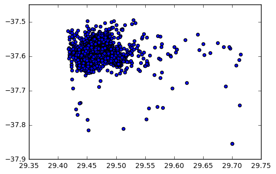

```python
plt.scatter(px, py)
```

- That's fine, but there are a number of problems.
- First, the markers are too big.
- Second, there are too many points; we could make them a bit transparent to have a better idea of the distribution of the points.
- Third, we may want to zoom a bit more around Manhattan.
- Fourth, the figure could be made bigger.
- And finally, we don't necessarily need the axes here.
- Fortunately matplotlib is highly customizable.

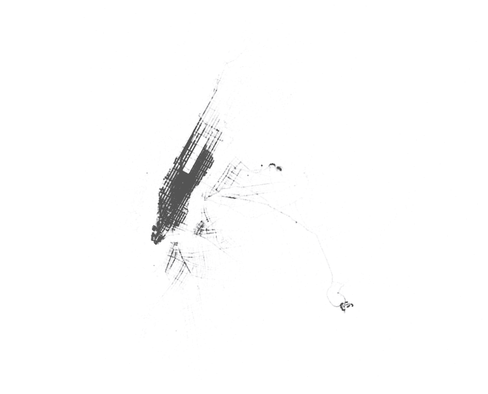

```python
plt.figure(figsize=(12, 10))
plt.axis('equal')
plt.xlim(29.40, 29.55)
plt.ylim(-37.63, -37.54)
plt.axis('off')
plt.gca().set_axis_bgcolor('white')
plt.scatter(px, py, s=.1, alpha=.03)
```

- The `figure()` function lets us specify the figure size (in inches).
- The `scatter()` function accepts many keyword arguments to customize the aspect of the scatter plot. Here:
  - We use a small marker size with the `s` keyword argument.
  - We use a small `alpha` opacity value: the points become nearly transparent, which emphasizes the regions with high density.
  - We use an equal aspect ratio with `axis('equal')`.
  - We zoom in by specifying the limits of the x and y axes with `xlim()` and `ylim()`.
  - We remove the axes with `axes('off')`.
  - We specify a white background with `set_axis_bgcolor('white')`; this is required to put a white background on the slide.

# Descriptive statistics with pandas and seaborn

- Common statistical quantities are one function call away in pandas.

```python
px.count(), px.min(), px.max()
```

```
(846945, 29.417137499999995, 29.714313055555561)
```

```python
px.mean(), px.median(), px.std()
```

```
(29.451345807768575, 29.449418333333337, 0.0097616942744512686)
```

- matplotlib is the main plotting package in Python.
- Although highly powerful and exible, it sometimes requires a significant amount of manual tuning in order to generate clean, high-quality, publication-ready gures.
- Several projects aim to offer higher-level, simpler user interfaces for high-quality plotting. Seaborn is one of them.
- To install Seaborn we need to do the following:
  - If we are using standard Python: `pip install seaborn` or `pip3 install seaborn`
  - If we are using the Anaconda distribution: `conda install seaborn -q -y`
- After everything has been installed, we should be able to import it for use.
- For more information on seaborn, see: http://stanford.edu/~mwaskom/software/seaborn/.

```python
import seaborn as sns

sns.__version__
```

```
'0.7.0'
```

- Let's display a histogram of the trip distances.
- pandas provides a few simple plotting methods for `DataFrame` and `Series` objects.
- These methods are based on matplotlib, and benefit from the seaborn styling if seaborn has been imported.
- The `hist()` method displays a histogram of the values of a `Series` object. We can specify the histogram bins with the `bins` keyword argument.
- Here, we use NumPy's `linspace()` function to generate 100 linearly-spaced bins between 0 and 10.

```python
np.linspace(0., 10., 100)
```

```
array([  0.        ,   0.1010101 ,   0.2020202 ,   0.3030303 ,
         0.4040404 ,   0.50505051,   0.60606061,   0.70707071,
         0.80808081,   0.90909091,   1.01010101,   1.11111111,
         1.21212121,   1.31313131,   1.41414141,   1.51515152,
         1.61616162,   1.71717172,   1.81818182,   1.91919192,
         2.02020202,   2.12121212,   2.22222222,   2.32323232,
         2.42424242,   2.52525253,   2.62626263,   2.72727273,
         2.82828283,   2.92929293,   3.03030303,   3.13131313,
         3.23232323,   3.33333333,   3.43434343,   3.53535354,
         3.63636364,   3.73737374,   3.83838384,   3.93939394,
         4.04040404,   4.14141414,   4.24242424,   4.34343434,
         4.44444444,   4.54545455,   4.64646465,   4.74747475,
         4.84848485,   4.94949495,   5.05050505,   5.15151515,
         5.25252525,   5.35353535,   5.45454545,   5.55555556,
         5.65656566,   5.75757576,   5.85858586,   5.95959596,
         6.06060606,   6.16161616,   6.26262626,   6.36363636,
         6.46464646,   6.56565657,   6.66666667,   6.76767677,
         6.86868687,   6.96969697,   7.07070707,   7.17171717,
         7.27272727,   7.37373737,   7.47474747,   7.57575758,
         7.67676768,   7.77777778,   7.87878788,   7.97979798,
         8.08080808,   8.18181818,   8.28282828,   8.38383838,
         8.48484848,   8.58585859,   8.68686869,   8.78787879,
         8.88888889,   8.98989899,   9.09090909,   9.19191919,
         9.29292929,   9.39393939,   9.49494949,   9.5959596 ,
         9.6969697 ,   9.7979798 ,   9.8989899 ,  10.        ])
```

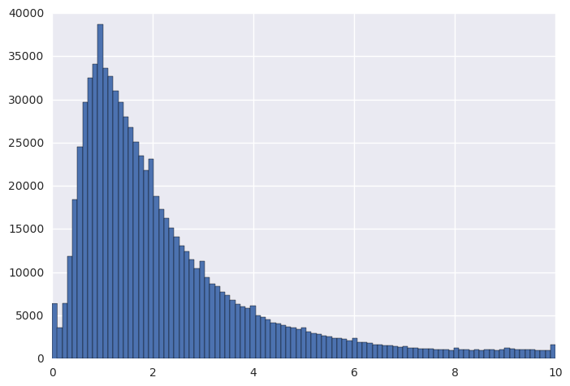

```python
data.trip_distance.hist(bins=np.linspace(0., 10., 100))
```

# Selecting data

- Our data set contains almost one million rows.
- Some analyses can be done by using the whole data set.
- Other interesting analyses can be made by looking at carefully-chosen subsets of the data.
- For example, what can we say about the taxi rides done on a particular day, a particular month, or a particular day of week?
- What about those starting or ending at a particular location?
- A significant part of real-world data analysis involves such fine-grained selections.

## Selecting Columns

```python
data[['trip_distance', 'trip_time_in_secs']].head(3)
```

|  | trip_distance | trip_time_in_secs |
| --- | --- | --- |
| 0 | 0.61 | 300 |
| 1 | 3.28 | 960 |
| 2 | 1.50 | 386 |

- In Python, the square brackets [] are used for selecting elements in a list.
- The same notation is used by pandas to select columns.
- We need two pairs of brackets because pandas expects a list of columns to select, here `['trip_distance', 'trip_time_ in_secs']`.
- The end-result is a new `DataFrame` containing just two columns instead of 14.

## Selecting Rows

- Rows of a `DataFrame` are indexed.
- Every row comes with a unique label (or index).
- Often, this label is just an integer between 0 and `n_rows-1`.
- In some situations, this label can be something else, like a string.
- If we had a `DataFrame` giving information about each taxi, the label could be the taxi's medallion (a unique identifer for NYC's taxicabs), or an anonymized version of it.
- The loc attribute of a `DataFrame` is used to select row(s) from their labels. Here, we select the first row.

```python
data.loc[0]
```

```
medallion             76942C3205E17D7E7FE5A9F709D16434
hack_license          25BA06A87905667AA1FE5990E33F0E2E
vendor_id                                          VTS
rate_code                                            1
store_and_fwd_flag                                 NaN
pickup_datetime                    2013-01-01 00:00:00
dropoff_datetime                   2013-01-01 00:05:00
passenger_count                                      3
trip_time_in_secs                                  300
trip_distance                                     0.61
pickup_longitude                              -73.9559
pickup_latitude                                40.7819
dropoff_longitude                             -73.9632
dropoff_latitude                               40.7778
Name: 0, dtype: object
```

- Multiple rows can be selected by providing a list of labels.

```python
data.loc[[0, 100000]]
```

|  | medallion | hack_license | vendor_id | rate_code | store_and_fwd_flag | pickup_datetime | dropoff_datetime | passenger_count | trip_time_in_secs | trip_distance | pickup_longitude | pickup_latitude | dropoff_longitude | dropoff_latitude |
| --- | --- | --- | --- | --- | --- | --- | --- | --- | --- | --- | --- | --- | --- | --- |
| 0 | 76942C3205E17D7E7FE5A9F709D16434 | 25BA06A87905667AA1FE5990E33F0E2E | VTS | 1 | NaN | 2013-01-01 00:00:00 | 2013-01-01 00:05:00 | 3 | 300 | 0.61 | -73.955925 | 40.781887 | -73.963181 | 40.777832 |
| 100000 | 7461F7106D33D3A5775F4245724606FD | BACEA353BB4106A005BB7836BDCAC0C3 | VTS | 1 | NaN | 2013-02-12 18:10:00 | 2013-02-12 18:20:00 | 2 | 600 | 2.02 | -73.966454 | 40.770512 | -73.958862 | 40.778042 |

```python
data.loc[1000:1100:10, ['trip_distance', 'trip_time_in_secs']]
```

|  | trip_distance | trip_time_in_secs |
| --- | --- | --- |
| 1000 | 1.00 | 441 |
| 1010 | 3.80 | 691 |
| 1020 | 0.00 | 7 |
| 1030 | 4.20 | 902 |
| 1040 | 3.40 | 1278 |
| 1050 | 1.00 | 242 |
| 1060 | 1.48 | 300 |
| 1070 | 3.03 | 600 |
| 1080 | 0.60 | 135 |
| 1090 | 2.80 | 780 |
| 1100 | 2.62 | 840 |

- Note how we combined column and row selection.
- Two expressions can be passed to `loc`: the row selection first, and the column selection second (the two expressions are separated by a comma).
- `loc` expects actual labels and, unlike normal Python slices, the start and end points are both inclusive.
- We could have used `iloc` instead of `loc` to specify index positions rather than labels.

## Filtering with Boolean Indexing

- Instead of selecting rows by labels, we can also select rows satisfying specific properties.
- This is a more common use-case in data analysis.
- For example, let's select the longest rides.
- `data.trip_distance>50` is a `Series` object containing boolean values for all rows, depending on whether the trip distance is higher or lower than 50.

```python
data.trip_distance>50
```

```
0         False
1         False
2         False
3         False
4         False
5         False
6         False
7         False
8         False
9         False
10        False
11        False
12        False
13        False
14        False
```

[output cut: 47 more lines]

- The `loc` attribute also works with booleans instead of explicit labels: it will return all rows represented by a `True` boolean value.
- This is the basis of filtering data with pandas.

```python
data.loc[data.trip_distance>50]
```

|  | medallion | hack_license | vendor_id | rate_code | store_and_fwd_flag | pickup_datetime | dropoff_datetime | passenger_count | trip_time_in_secs | trip_distance | pickup_longitude | pickup_latitude | dropoff_longitude | dropoff_latitude |
| --- | --- | --- | --- | --- | --- | --- | --- | --- | --- | --- | --- | --- | --- | --- |
| 1853 | DA2A0A9EBD9AFD25013CF83805B61D6D | A3BCE60F48302B63C4B7AAE443960704 | CMT | 1 | N | 2013-01-01 21:41:03 | 2013-01-01 21:56:37 | 1 | 934 | 52.20 | -73.979576 | 40.743626 | -73.941902 | 40.807281 |
| 6316 | 6BD1B641A1CD55803A21560299B985A7 | A33DB5A909ADBFCE2AB057264141C8E9 | CMT | 1 | N | 2013-01-04 06:44:21 | 2013-01-04 07:17:14 | 1 | 1973 | 96.30 | -73.959785 | 40.762497 | -73.962440 | 40.662910 |
| 8683 | E95D27A43DC7A5F0C015409386BB49DB | 8A6EB7FA7E6A3F4A50C717871C068D72 | CMT | 1 | N | 2013-01-05 01:51:08 | 2013-01-05 02:23:01 | 1 | 1913 | 52.90 | -74.006119 | 40.735157 | -73.958694 | 40.714905 |
| 24381 | A38882246FC6439948FA470459F94134 | 8A60E3668580091A4BB124E9BDAFDD89 | CMT | 1 | N | 2013-01-12 03:02:55 | 2013-01-12 03:24:47 | 1 | 1312 | 66.20 | -73.966873 | 40.683315 | -73.916885 | 40.754852 |
| 54723 | 0F48C5AE255A294B4E88ECC3CED0CFC5 | C92D893B061C29C152ADF42B15317C3E | CMT | 5 | N | 2013-01-24 21:07:13 | 2013-01-24 21:31:44 | 1 | 1471 | 79.40 | -73.885735 | 40.771580 | -73.984947 | 40.758060 |
| 90068 | 7B59F6023736C5217B613D17B4ED6A9C | F2D89276E3886C6A8D27AE463637FF36 | CMT | 1 | N | 2013-02-08 01:54:21 | 2013-02-08 02:02:03 | 1 | 461 | 70.90 | -73.985512 | 40.742313 | -73.993950 | 40.720837 |
| 115471 | FB0FAE6EABFE14F45600AD382B52EFE5 | 0D39DD3359634605EAC8B451295E8186 | CMT | 1 | N | 2013-02-18 19:52:08 | 2013-02-18 20:07:33 | 1 | 925 | 67.20 | -73.874474 | 40.773975 | -73.937866 | 40.723824 |
| 119002 | A51E7B7371667690E65D88307FBBA229 | 3A6EDD62A2933A11545527FDE55DAC52 | CMT | 1 | N | 2013-02-20 12:20:03 | 2013-02-20 12:43:12 | 1 | 1389 | 87.90 | -73.862915 | 40.769157 | -73.973579 | 40.748199 |
| 134839 | FA189EABBB4058AC0359AA1CF30F5313 | C707B5A8C6AEF269564272AF66B37564 | CMT | 1 | Y | 2013-02-26 17:54:11 | 2013-02-26 18:45:03 | 1 | 3052 | 69.80 | -73.989853 | 40.729340 | -73.964035 | 40.771950 |
| 157050 | C4580AE98B332B1E4B6B822B1C2D03BE | E2CB66B7D37105F7C3364DFF61E4D487 | VTS | 2 | NaN | 2013-03-07 12:34:00 | 2013-03-07 15:24:00 | 6 | 10200 | 60.14 | -73.777405 | 40.646626 | -73.982193 | 40.769535 |
| 201876 | DBCD64B365502F85569B4A264B798AAE | D404427B22B187FE0460668FDEC9937E | CMT | 1 | N | 2013-03-25 09:30:28 | 2013-03-25 10:07:32 | 2 | 2224 | 61.00 | -73.988136 | 40.749702 | -73.887688 | 40.859402 |
| 210667 | BD4738379B8C2E8168F48CFFDE2F94E6 | E6F2B8515FE5A32AACF884FBA21F0170 | CMT | 1 | N | 2013-03-28 23:25:31 | 2013-03-28 23:36:47 | 1 | 675 | 52.50 | -73.979370 | 40.766933 | -73.992043 | 40.759903 |
| 238505 | 4ADDFBA1E3FD055AB4854D003976F263 | 2B09130C92CF5199315044DFE89D6356 | CMT | 1 | N | 2013-04-09 15:10:48 | 2013-04-09 15:19:54 | 1 | 545 | 85.30 | -73.979851 | 40.764091 | -73.982155 | 40.777206 |
| 305690 | A895384C359AABDA144AF574989DA1C3 | CEEB6BCC5E4705A32043BCA2DBA78E3E | CMT | 1 | N | 2013-05-06 12:35:03 | 2013-05-06 12:45:28 | 1 | 623 | 50.50 | -73.978287 | 40.773117 | -73.978287 | 40.773117 |
| 450941 | 849397BEC809E0CBF9FF645FE7FD96A8 | BC7E6894AF102A345E3D050121FAA1F2 | CMT | 1 | N | 2013-07-09 13:51:02 | 2013-07-09 14:13:53 | 4 | 1371 | 88.00 | -73.987518 | 40.747070 | -73.870758 | 40.772087 |
| 504497 | 7237EC7ABD6114EDDC87A3AA846F8418 | D52502537E2DF62C9BFFECF5A387E7E9 | CMT | 1 | N | 2013-08-02 11:22:31 | 2013-08-02 11:33:03 | 1 | 631 | 6005123.00 | -73.997467 | 40.736397 | -73.991882 | 40.764629 |
| 507107 | 50DA72F510E2F84A42712E13744FAC7B | EA9D03A766C1D32A6668FFF0C1EB4E4B | CMT | 1 | N | 2013-08-04 18:42:17 | 2013-08-04 20:37:19 | 3 | 4290965 | 181.80 | -73.978020 | 40.765167 | -73.815041 | 40.730076 |
| 520570 | 68FADA2827FA3A1AB0FF32EC47F565EB | 1E68C0830B73658C43635CAD45ECFDFA | CMT | 0 | N | 2013-08-10 23:27:49 | 2013-08-10 23:27:49 | 1 | 0 | 57.70 | -73.956726 | 40.767033 | -73.956726 | 40.767033 |
| 548988 | A978A0AAE9B2CFEE310FACD97A09C319 | CE56A27F53ABF411094B6CD708BFBA96 | CMT | 1 | N | 2013-08-24 17:03:27 | 2013-08-24 17:03:29 | 1 | 1 | 442.00 | -73.993896 | 40.702644 | -73.993874 | 40.702637 |
| 558665 | 5A5C516A820FE476E9D3E14101B669AC | C24585AA866FC76A4E09A05F55DC7E54 | CMT | 2 | N | 2013-08-29 10:01:40 | 2013-08-29 11:52:20 | 1 | 6640 | 164.40 | -73.791534 | 40.661026 | -73.983734 | 40.765778 |
| 659208 | E8E54922CFDFC480893C1E2021506CD4 | BCCAFB9AB09496225A0FE39096FD72C0 | VTS | 1 | NaN | 2013-10-11 14:43:00 | 2013-10-11 16:27:00 | 1 | 6240 | 55.80 | -73.776817 | 40.645065 | -73.806770 | 40.659180 |
| 672612 | 9B14258B0E3EF13923996FB8537B2EA0 | 42834D2C6C221FDA7CDAE3AC95A981D3 | VTS | 2 | NaN | 2013-10-17 11:44:00 | 2013-10-17 13:58:00 | 5 | 8040 | 52.00 | -73.790825 | 40.662148 | -73.983200 | 40.745365 |

- We might want to choose the distance threshold depending on certain conditions.
- For example, we might want to keep the 1% longest trips.

```python
data.loc[data.trip_distance >= data.trip_distance.quantile(0.99)]
```

|  | medallion | hack_license | vendor_id | rate_code | store_and_fwd_flag | pickup_datetime | dropoff_datetime | passenger_count | trip_time_in_secs | trip_distance | pickup_longitude | pickup_latitude | dropoff_longitude | dropoff_latitude |
| --- | --- | --- | --- | --- | --- | --- | --- | --- | --- | --- | --- | --- | --- | --- |
| 85 | FAE1370A694D0621FAE1E62FAFD64080 | 22133BD8EC624A82457E34D5A5A183BB | CMT | 1 | N | 2013-01-01 00:37:04 | 2013-01-01 01:04:23 | 1 | 1639 | 18.10 | -73.790123 | 40.646439 | -73.972939 | 40.688129 |
| 754 | EFBD4CDDE5EE1023AF976B770F237014 | 828A962E838348FEC0494FC8FCC0C5AC | CMT | 2 | N | 2013-01-01 06:57:35 | 2013-01-01 07:28:22 | 4 | 1846 | 24.00 | -73.788399 | 40.647346 | -74.017143 | 40.707912 |
| 761 | 1E65B7E2D1297CF3B2CA87888C05FE43 | 78720D2C78774F81A6D60A57DEBF18F2 | VTS | 1 | NaN | 2013-01-01 07:09:00 | 2013-01-01 07:40:00 | 2 | 1860 | 20.06 | -73.973007 | 40.756313 | -73.959724 | 40.762032 |
| 866 | D6223E5B55B9C1DB16DCC6F88A25237D | 872E61E6714AED851CC521C1EAD52746 | CMT | 1 | N | 2013-01-01 10:24:20 | 2013-01-01 11:05:03 | 1 | 2442 | 19.00 | -73.776726 | 40.645187 | -73.909943 | 40.702976 |
| 875 | C6315C5FA4E83F9147EAF36B75F1577F | E113D75C36B2DC3246739372222D957A | VTS | 1 | NaN | 2013-01-01 10:34:00 | 2013-01-01 10:59:00 | 1 | 1500 | 19.39 | -73.862755 | 40.768826 | -74.037804 | 40.615582 |
| 896 | 429AD5759D9F317802F3A6C5F138E7B9 | 89336881692B4BAFFB41733FF34175DB | CMT | 1 | N | 2013-01-01 10:50:59 | 2013-01-01 11:35:11 | 1 | 2652 | 22.60 | -73.983963 | 40.760532 | -73.970749 | 40.766586 |
| 1051 | 4E67DD5E52DAD3CC9F8C84132F96AD2D | E62020D2D3AA474C673B0DA6555B3EF0 | CMT | 2 | N | 2013-01-01 12:53:54 | 2013-01-01 13:23:10 | 1 | 1755 | 18.70 | -74.004753 | 40.721218 | -73.776344 | 40.645626 |
| 1067 | D8AADA4E722C87C10E609654612630DD | 8F1E4F779A4D67431C3FCFA4E70A87DC | CMT | 2 | N | 2013-01-01 13:01:21 | 2013-01-01 13:34:07 | 1 | 1965 | 19.00 | -73.788589 | 40.641483 | -74.002174 | 40.734898 |
| 1112 | 989CCA4181187B1C9FBD7AA3CC0DF6B1 | A47B576CD8F45A39BFEFCF496896065B | CMT | 2 | Y | 2013-01-01 13:28:04 | 2013-01-01 13:55:17 | 4 | 1633 | 20.10 | -74.012985 | 40.703053 | -73.789864 | 40.643162 |
| 1151 | A5D941D4834813EF4C394713A613A93E | 82084C88A840B1F8DDD73E7F91ABD383 | VTS | 2 | NaN | 2013-01-01 13:49:00 | 2013-01-01 14:17:00 | 1 | 1680 | 18.29 | -73.783295 | 40.648582 | -73.978989 | 40.762283 |
| 1259 | 20DEC2EBA19D9AD90627DADA0C4FB5C6 | D60E9DAE12C6F783FE52C3EEF18C6D76 | VTS | 1 | NaN | 2013-01-01 15:08:00 | 2013-01-01 15:45:00 | 5 | 2220 | 19.19 | -73.790604 | 40.643696 | -73.990860 | 40.702530 |
| 1281 | E9470D42CFE241DBF2015A1995E81F0B | D95969E94B630E4761EC4BA2F174E6B6 | VTS | 5 | NaN | 2013-01-01 15:21:00 | 2013-01-01 16:03:00 | 1 | 2520 | 21.64 | -73.796799 | 40.644726 | -74.000595 | 40.791161 |
| 1425 | CE479EA6CBA8CF17B3C7D84A218FB42C | 26D53D3141847BA144D41662D24B42B0 | CMT | 2 | N | 2013-01-01 16:59:55 | 2013-01-01 17:38:33 | 1 | 2317 | 19.40 | -73.789574 | 40.647045 | -73.948921 | 40.829941 |
| 1434 | EE8D55EE93F313FBE0BD7B10BFFD66EE | 85FBAA801C51CF31386AF203EB5F8DC4 | VTS | 2 | NaN | 2013-01-01 17:04:00 | 2013-01-01 17:37:00 | 1 | 1980 | 18.51 | -73.790367 | 40.643761 | -73.996048 | 40.720993 |
| 1467 | 1A292EA0C31E7673162FB4147D7D086D | 02719FF11ED7BEE6DE17194E4A042E0D | VTS | 2 | NaN | 2013-01-01 17:23:00 | 2013-01-01 18:03:00 | 1 | 2400 | 19.62 | -73.789253 | 40.642319 | -74.003807 | 40.733498 |
| 1530 | CFDC2FD1EA126311658E5421361D1ABE | 94036EB101FCE99ED628A47C91EE252C | CMT | 2 | N | 2013-01-01 18:05:39 | 2013-01-01 18:37:58 | 2 | 1939 | 19.50 | -73.781921 | 40.644707 | -73.952934 | 40.780296 |
| 1576 | 0EB253AE94130E03868E1B1B6DA0AB82 | FF421629E07FBEF405B1A8BC58BA989B | VTS | 2 | NaN | 2013-01-01 18:34:00 | 2013-01-01 19:04:00 | 5 | 1800 | 19.96 | -73.776779 | 40.645233 | -73.957718 | 40.776237 |
| 1585 | 49F90D09F4B18C950DB34C9837FD5F6E | EE8B542B14C1B549ED1B445F07BA84B0 | VTS | 2 | NaN | 2013-01-01 18:41:00 | 2013-01-01 19:14:00 | 1 | 1980 | 20.50 | -73.972099 | 40.781513 | -73.789795 | 40.647030 |
| 1655 | 35C25E22F6ABB6966B7416421F777A0F | 70CBFF9F04A11C008233A1F7DB5EDFC9 | CMT | 2 | N | 2013-01-01 19:31:14 | 2013-01-01 20:02:47 | 2 | 1892 | 19.00 | -73.789772 | 40.646671 | -73.968437 | 40.787491 |
| 1714 | 47981D5BBC648829C44EF0110879A695 | BB8018A0565AB7F8FCCDEE7977A85664 | VTS | 2 | NaN | 2013-01-01 20:08:00 | 2013-01-01 20:44:00 | 1 | 2160 | 21.43 | -73.789902 | 40.643799 | -74.013268 | 40.716049 |
| 1726 | 0A98C39EFB8FC144AD266417455C13F3 | 67AC4A4D63825D4D00AB19A5A95BF63C | VTS | 2 | NaN | 2013-01-01 20:17:00 | 2013-01-01 20:55:00 | 1 | 2280 | 20.94 | -73.782120 | 40.644756 | -73.972588 | 40.780975 |
| 1849 | A08A83664306C700B45E2801B09977D8 | 84D58932D306DDE58D210B7465912D2E | CMT | 1 | N | 2013-01-01 21:38:43 | 2013-01-01 21:49:41 | 1 | 658 | 24.50 | -73.985748 | 40.752773 | -73.953506 | 40.766575 |
| 1853 | DA2A0A9EBD9AFD25013CF83805B61D6D | A3BCE60F48302B63C4B7AAE443960704 | CMT | 1 | N | 2013-01-01 21:41:03 | 2013-01-01 21:56:37 | 1 | 934 | 52.20 | -73.979576 | 40.743626 | -73.941902 | 40.807281 |
| 1896 | 441265A2DCA52245AE652E4D5C18E665 | 2C5E9C24BD0F520BA28AC72259DA74C2 | CMT | 2 | N | 2013-01-01 22:16:05 | 2013-01-01 22:49:45 | 1 | 2020 | 18.30 | -73.789795 | 40.643734 | -73.985435 | 40.764481 |
| 1998 | 348F65209270BEDAE8D8E8BC0C2C0A6B | B0562F5346DA1EBD50C0C0EFA8EB8548 | CMT | 2 | N | 2013-01-01 23:33:13 | 2013-01-01 23:58:51 | 1 | 1537 | 20.70 | -73.782043 | 40.644592 | -73.936806 | 40.847210 |
| 2039 | E9E4605C9790B5891207F0D87A973B33 | E4566BD5739A97ABD299550FF7E81D12 | VTS | 2 | NaN | 2013-01-02 00:19:00 | 2013-01-02 00:45:00 | 1 | 1560 | 20.02 | -73.776695 | 40.645378 | -73.957779 | 40.773415 |
| 2049 | 851150F6C33767D8CC8B698B8C1FB26A | 1982D4B101B4CAD94422211BCA966CB3 | CMT | 2 | N | 2013-01-02 00:33:17 | 2013-01-02 01:00:19 | 1 | 1621 | 19.60 | -73.783524 | 40.648579 | -74.009506 | 40.721439 |
| 2086 | EEF7C5160FE5886A2E8806123B2D37BE | 9A5656C8409016FCA3BDF173C7F43176 | CMT | 1 | N | 2013-01-02 01:43:10 | 2013-01-02 02:13:28 | 1 | 1818 | 48.00 | -73.990257 | 40.756592 | -73.949104 | 40.784634 |
| 2130 | C97774CC21855CB0CC7CFAD95C9FF657 | 89083A4C73512D09E3F088CFFC51CD47 | CMT | 2 | N | 2013-01-02 05:45:27 | 2013-01-02 06:20:28 | 1 | 2100 | 22.00 | -73.783562 | 40.648586 | -74.016037 | 40.711338 |
| 2132 | 2ED0495D9F085375048BF71D5F51A23E | D5FA3FA0A3ADDEBDB44DB29049F0BD2E | CMT | 2 | N | 2013-01-02 05:50:23 | 2013-01-02 06:35:26 | 1 | 2703 | 19.60 | -73.780556 | 40.645260 | -73.974625 | 40.785034 |
| ... | ... | ... | ... | ... | ... | ... | ... | ... | ... | ... | ... | ... | ... | ... |
| 843870 | 3CACE6A20EB462544D4F0F3DA1303EDC | 130328475AD7427AFDE50A846CA08B22 | VTS | 2 | NaN | 2013-12-30 17:48:00 | 2013-12-30 18:36:00 | 2 | 2880 | 21.81 | -73.781845 | 40.644730 | -74.010681 | 40.704540 |
| 844039 | 9406D2C34715E1DA10AD4D4DDADF4DA5 | 0602DFD837433635FE860BDE2F14BC3A | VTS | 2 | NaN | 2013-12-30 18:59:00 | 2013-12-30 19:39:00 | 2 | 2400 | 18.31 | -73.963043 | 40.799091 | -73.791512 | 40.644501 |
| 844088 | A959860D971E2349258BA6E55CFA0CC2 | A9A81CE2EAE599C02337A70462E38996 | CMT | 2 | N | 2013-12-30 19:17:30 | 2013-12-30 19:58:57 | 1 | 2486 | 19.80 | -73.790092 | 40.643726 | -73.954445 | 40.775486 |
| 844282 | 6BCA6CE04F3A2391FCA2CACC1EEB3CD3 | 92DAB97C0E3EA722A261E035F96B1A03 | VTS | 2 | NaN | 2013-12-30 20:39:00 | 2013-12-30 21:17:00 | 5 | 2280 | 18.27 | -73.781113 | 40.645023 | -73.988594 | 40.764095 |
| 844308 | 83D19F7D4A52B852528AB03FF71BFDC9 | AEF88B80E43BCF2C08C344F03F813787 | VTS | 2 | NaN | 2013-12-30 20:51:00 | 2013-12-30 21:21:00 | 2 | 1800 | 18.91 | -73.790085 | 40.643890 | -73.998047 | 40.721027 |
| 844324 | B098A16959E4408CEDF818756C09DD33 | 6AB832812C1D4D423B7C00B9942762E8 | CMT | 2 | N | 2013-12-30 20:59:00 | 2013-12-30 21:32:17 | 3 | 1997 | 20.60 | -73.788315 | 40.641808 | -74.004692 | 40.706898 |
| 844332 | F0D3979014729585E8D6E2AE3EC3B1FD | 82D0D0BDE2C1571AF7FEB0559DB25ED9 | CMT | 2 | N | 2013-12-30 21:02:21 | 2013-12-30 21:34:53 | 1 | 1952 | 22.00 | -73.776779 | 40.645618 | -74.009445 | 40.704647 |
| 844415 | CEF3D32468307B1DEAD7A6E72A97C8CA | 3E0CA384EFAA3E6A5989B51DF4F29E39 | VTS | 2 | NaN | 2013-12-30 21:49:00 | 2013-12-30 22:26:00 | 1 | 2220 | 18.72 | -73.781136 | 40.644978 | -74.000496 | 40.744553 |
| 844597 | C458AB315624059876C48E6B01E23678 | A09613CA044AC26F30E2C18F024BB73D | CMT | 1 | N | 2013-12-30 23:37:10 | 2013-12-31 00:09:36 | 1 | 1946 | 21.30 | -73.776756 | 40.645370 | -74.007820 | 40.632568 |
| 844612 | B5EB446D51AF2B3A8EC944B015D202FA | 3E8FAD5E45C74A16FDF1E1BD70841498 | VTS | 2 | NaN | 2013-12-30 23:45:00 | 2013-12-31 00:13:00 | 1 | 1680 | 18.59 | -73.781105 | 40.645054 | -73.995598 | 40.733360 |
| 844675 | DF02E8BC25548C931BC0D59DE1F6B7B6 | C3776E8A973848D20C18D5DC10EDF5B5 | CMT | 2 | N | 2013-12-31 00:21:31 | 2013-12-31 00:49:12 | 1 | 1660 | 20.70 | -73.782013 | 40.644726 | -74.007484 | 40.706062 |
| 844700 | 27520D444D1769FEB01940F51DAD1141 | EF687A5010940CC045350202149B5862 | VTS | 2 | NaN | 2013-12-31 00:36:00 | 2013-12-31 01:05:00 | 1 | 1740 | 18.04 | -73.781105 | 40.645073 | -73.978561 | 40.772438 |
| 844911 | 26B6B5EA600ECB6E92CA40CDC270AC59 | AB8DB4110F0AE485C8BC9B777B41023F | VTS | 2 | NaN | 2013-12-31 06:07:00 | 2013-12-31 06:59:00 | 1 | 3120 | 31.08 | -73.814865 | 40.699429 | -73.782219 | 40.648701 |
| 844955 | 6B943DA2BDA9D93BBE5D4874F5F4D951 | C37FA884E48CE5069E1A9A787C9869A6 | VTS | 2 | NaN | 2013-12-31 07:05:00 | 2013-12-31 07:32:00 | 1 | 1620 | 19.00 | -73.781090 | 40.645031 | -73.999756 | 40.715240 |
| 844960 | B672154F0FD3D6B5277580C3B7CBBF8E | CB9A1B34D762F58FDAD810926FD22429 | VTS | 2 | NaN | 2013-12-31 07:13:00 | 2013-12-31 07:44:00 | 1 | 1860 | 19.05 | -73.957634 | 40.773888 | -73.776566 | 40.645000 |
| 844984 | FD3BA4AA4E1125787E8D857AF30C837D | DB7667FE1689C5377F87BD64571F2375 | CMT | 2 | N | 2013-12-31 07:41:22 | 2013-12-31 08:16:32 | 1 | 2109 | 20.50 | -73.981293 | 40.779911 | -73.788963 | 40.641502 |
| 844994 | A1544A7470D936F7E93B7BAEECBFC7DC | 89083A4C73512D09E3F088CFFC51CD47 | CMT | 2 | N | 2013-12-31 07:48:08 | 2013-12-31 08:28:16 | 2 | 2407 | 18.30 | -73.776894 | 40.645329 | -73.978416 | 40.762081 |
| 845048 | 630D03E962DDA5EA9035059BE8A76E03 | 6B20AD78F3AC43B48FB1447581CA09F3 | CMT | 1 | N | 2013-12-31 08:44:42 | 2013-12-31 10:23:25 | 2 | 5922 | 20.40 | -73.989334 | 40.750732 | -73.948334 | 40.680279 |
| 845178 | 99F1C8935E783A5DA83A2A37A15F45D1 | 0D4A187C5A38980CBBD645817F52BD22 | CMT | 2 | N | 2013-12-31 10:24:25 | 2013-12-31 10:52:49 | 1 | 1704 | 18.60 | -73.954285 | 40.774517 | -73.782173 | 40.644241 |
| 845192 | 7FDEB279D31CE6E5AF16203871B07AAC | 856397F5B1CCB5DA44DDBF0EF1F1DE2D | VTS | 1 | NaN | 2013-12-31 10:35:00 | 2013-12-31 11:12:00 | 2 | 2220 | 18.27 | -73.782349 | 40.644634 | -73.969048 | 40.623924 |
| 845770 | B83044D63E9421B76011917CE280C137 | 8125587C6E782164D89DAE7AA13DD75A | VTS | 2 | NaN | 2013-12-31 15:31:00 | 2013-12-31 16:11:00 | 1 | 2400 | 18.35 | -73.786034 | 40.647346 | -73.977631 | 40.722820 |
| 845822 | AE5C649E7781FE39E041FA4E743A8B4A | 59B3FCEEB220FDAB85EB0E4F058269AC | CMT | 1 | N | 2013-12-31 16:00:21 | 2013-12-31 16:43:54 | 3 | 2612 | 18.60 | -73.783516 | 40.648598 | -73.974335 | 40.645908 |
| 845832 | E858A763A7CEF0DDFB1DB4A6669D0CBA | 745575BA9559B5AFE22079135A3B7F5D | CMT | 1 | N | 2013-12-31 16:05:10 | 2013-12-31 16:48:25 | 1 | 2594 | 25.60 | -73.776787 | 40.645390 | -73.864395 | 40.900749 |
| 845841 | 6483B9BFCB216EC88986EA3AB13064E7 | 8A6F25B1F3D56E03C30D01E9F9020B50 | VTS | 2 | NaN | 2013-12-31 16:08:00 | 2013-12-31 16:44:00 | 1 | 2160 | 18.56 | -73.781845 | 40.644806 | -73.994499 | 40.723801 |
| 845886 | C8B3E26B786B9CDA6B5EB27CE779347B | F7F24E29712B3C3BAFDF7CF1B229C686 | VTS | 2 | NaN | 2013-12-31 16:41:00 | 2013-12-31 17:17:00 | 6 | 2160 | 18.17 | -73.802994 | 40.648224 | -74.004959 | 40.737331 |
| 845913 | 0CDF4F00D2DE12783154BDCE0E6901E5 | 5B0D6BECE81C5604DEF37A2CF9D5EDD6 | CMT | 1 | N | 2013-12-31 16:52:15 | 2013-12-31 17:32:34 | 4 | 2418 | 18.10 | -73.781883 | 40.644558 | -73.971512 | 40.686337 |
| 846147 | 41A9848FCA764BCBC8C0C370611C9F14 | BB04D24D88C031A8883A5E8FB75DAF06 | VTS | 2 | NaN | 2013-12-31 18:41:00 | 2013-12-31 19:11:00 | 2 | 1800 | 18.28 | -73.781937 | 40.644806 | -73.988937 | 40.740356 |
| 846211 | 5D813194D05170E70DAAFAF07BB24FD9 | 78AF0265753324EA393256E800A1843B | VTS | 2 | NaN | 2013-12-31 19:17:00 | 2013-12-31 19:51:00 | 1 | 2040 | 20.45 | -73.794258 | 40.644909 | -73.978996 | 40.782482 |
| 846506 | B733B08AD4B8C4DAB7B2134D39D8BCB5 | 220680BCA0FDEA551E2768740A8F3DDE | VTS | 2 | NaN | 2013-12-31 21:06:00 | 2013-12-31 21:37:00 | 1 | 1860 | 19.15 | -73.781860 | 40.644684 | -73.960617 | 40.816223 |
| 846571 | 93EC0E01A8D4F29F4BD85319F94A65DB | 7101E61AA3D80D8A7FF855F32073A33F | VTS | 1 | NaN | 2013-12-31 21:25:00 | 2013-12-31 21:52:00 | 4 | 1620 | 19.47 | -73.776863 | 40.645481 | -73.889732 | 40.825146 |

8705 rows × 14 columns

# Computing with Numbers

- The `trip_time_in_secs column` contains the trip durations in seconds. How can we convert these values to minutes?
- More generally, how can we make computations on DataFrames?
- A first approach would be to use a for loop, iterating over all rows and making numerical computations successively inside that loop. This is not the best way to do it.
- Whereas Python loops are possible in this situation, they would be extremely slow. For this reason, they should be avoided as much as possible.
- pandas allows you to perform vector operations on `DataFrame` and `Series` objects. These operations are quite natural, because they follow standard mathematical notations. For example, let's add a new column containing the trip durations in minutes.

```python
data['trip_time_in_mins'] = data.trip_time_in_secs / 60.0

data[['trip_time_in_secs', 'trip_time_in_mins']].head(3)
```

|  | trip_time_in_secs | trip_time_in_mins |
| --- | --- | --- |
| 0 | 300 | 5.000000 |
| 1 | 960 | 16.000000 |
| 2 | 386 | 6.433333 |

- The `data.trip_time_in_secs` notation represents a `Series` object.
- The `/` symbol represents floating-point division in Python 3.
- It normally works with numbers only. However, pandas extends this operator to work with Series and DataFrames as well, in which case it automatically operates on all elements.
- Here, all elements of `data.trip_time_in_secs` are divided by 60.
- The same notation would also work if we had another `Series` object of the same size in the second term.
- In that case, the division would occur on an element-wise basis.
- The first item in the Series on the left would be divided by the first in the right, the second by the second, and so on.
- A `Series` object is a vector with indices (or labels). The indices determine which values are used when operating Series objects together.

```python
a = data.trip_distance[:5]
a
```

```
0    0.61
1    3.28
2    1.50
3    0.00
4    1.31
Name: trip_distance, dtype: float64
```

```python
b = data.trip_distance[2:6]
b
```

```
2    1.50
3    0.00
4    1.31
5    5.81
Name: trip_distance, dtype: float64
```

- These two `Series` objects have different but overlapping sets of indices.
- Although they don't have the same size, we can add them together.

```python
 a + b
```

```
0     NaN
1     NaN
2    3.00
3    0.00
4    2.62
5     NaN
Name: trip_distance, dtype: float64
```

- The result is a new `Series` object containing the *aligned* sum of `a` and `b`.
- The set of indices of `a + b` is the union of the indices of `a` and `b`.
- When one value is missing, we get an operation with an undefined value, which is `NaN` (Not a Number).
- When the indices overlap, the sum is correctly computed. This feature, *alignment*, makes it quite convenient to operate on labeled data.
- Other mathematical operations (`+`, `*`, etc.) work similarly.
- Furthermore, NumPy implements many mathematical functions like `np.log()` and `np.sin()`.
- They not only work on scalar numbers but also on Series and DataFrames.
- This is called vectorization, because this concept relates to mathematical operations performed on vectors.

# Working with Text

- Efficient vectorized operations can also be done on text. Let's have a look at `data.medallion`.

```python
data.medallion.head(3)
```

```
0    76942C3205E17D7E7FE5A9F709D16434
1    517C6B330DBB3F055D007B07512628B3
2    ED15611F168E41B33619C83D900FE266
Name: medallion, dtype: object
```

- This column contains anonymized versions of the taxis' medallions.
- The `str` attribute gives us access to many vectorized string processing functions.
- Here, for example, we extract the first four characters of every medallion.

```python
data.medallion.str.slice(0, 4).head(3)
```

```
0    7694
1    517C
2    ED15
Name: medallion, dtype: object
```

- There are many more methods for manipulating strings (text).
- For example, we can find strings that match a particular *regular expression*.
- Here is how we can find the rows with medallions that start with two digits.

```python
data.medallion.str.findall(r'^\d{2}.*').head(10)
```

```
0    [76942C3205E17D7E7FE5A9F709D16434]
1    [517C6B330DBB3F055D007B07512628B3]
2                                    []
3                                    []
4                                    []
5    [61E558C4FCB0BCB8562FC37B06B97FFE]
6    [36EDC01D57A6489E2DEE50734ECB327D]
7    [131162C7685521FA81608D3C42E4EF29]
8    [22467390B5CCC51FD1B12659F6084B2F]
9    [939D5E5E9555C02F0DB5B4B4F2D6BCBC]
Name: medallion, dtype: object
```

- If we want to actually filter these rows, then we use `str.contains()`, which returns a `Series` of `True` and `False` values:

```python
data.medallion.str.contains(r'^\d{2}.*').head(10)
```

```
0     True
1     True
2    False
3    False
4    False
5     True
6     True
7     True
8     True
9     True
Name: medallion, dtype: bool
```

- Then we can index `data.medallion` based on the results of `str.contains()`.

```python
data.medallion[data.medallion.str.contains(r'^\d{2}.*')].head(10)
```

```
0     76942C3205E17D7E7FE5A9F709D16434
1     517C6B330DBB3F055D007B07512628B3
5     61E558C4FCB0BCB8562FC37B06B97FFE
6     36EDC01D57A6489E2DEE50734ECB327D
7     131162C7685521FA81608D3C42E4EF29
8     22467390B5CCC51FD1B12659F6084B2F
9     939D5E5E9555C02F0DB5B4B4F2D6BCBC
12    204BAB16D3382C5A5711068B28E624C2
14    6941E9EA4BCD679F7F2F6053F8150195
20    7257A55FFAB4C29F08A9A40F510FC2B6
Name: medallion, dtype: object
```

## Regular Expressions

- In Python regular expressions are available through the `re` library, but in Pandas we can use them directly.
- They are essentially a mini language for matching strings.
- Most characters match themselves
- The following characters are special:

```
. ^ $ * + ? { } [ ] \ | ( )
```

- See the [Wikipedia regular expressions article](https://en.wikipedia.org/wiki/Regular_expression) and the related [Python documentation](https://docs.python.org/3.5/library/re.html).
- The character `^` matches the beginning of a line.
- The character `$` matches the end of a line.
- The characters `[` and `]` define character classes.
- `[a-z]` defines the characters from `a` to `z`.
- `[akm$]` matches any of the characters `a`, `k`, `m`, `$`.
- If the first character in the brackets is `^` we complement the class. So, `[^a-z]` means any character *apart* from the characters from `a` to `z`.
- `.` matches any character.
- `\d` matches any decimal digit; this is equivalent to the class `[0-9]`.
- `\D` matches any non-digit character; this is equivalent to the class `[^0-9]`.
- `\s` matches any whitespace character; this is equivalent to the class `[ \t\n\r\f\v]`.
- `\S` matches any non-whitespace character; this is equivalent to the class `[^ \t\n\r\f\v]`.
- `\w` matches any alphanumeric character; this is equivalent to the class `[a-zA-Z0-9_]`.
- `\W` matches any non-alphanumeric character; this is equivalent to the class `[^a-zA-Z0-9_]`.
- `\` escapes a character.
- The `*` character means zero or more times the preceding character. For example, `ca*t` will match ct, cat, caat, etc.
- The `+` character means one or more times the preceding character. For example, `ca+t` will match cat, caat, etc. but not ct
- The `?` character means zero or one time the preceding character.
- For example, the regular expression `a[bcd]*b` means: any string that starts with `a`, is followed by zero or more of the characters `b`, `c`, `d`, and then the character `b`.
- `{m, n}` will match the preceding character from `m` up to and including `n` times. For example, `ba{2, 5}b` will match baab, baaab, baaaab, baaaaab.
- The `|` character is a logical or.
- `[hc]+at` matches "hat", "cat", "hhat", "chat", "hcat", "cchchat", and so on, but not "at".
- `[hc]?at` matches "hat", "cat", and "at".
- `cat|dog` matches "cat" or "dog".
- `cat|[dog]{3}` matches "cat", or "dog", or "god", or "ogd", ...
- `cat|dog|god` matches "cat", or "dog", or "god".
- The following regular expression matches (some) e-mail addresses:

```
"^[a-zA-Z0-9_.+-]+@[a-zA-Z0-9-]+\.[a-zA-Z0-9-.]+$"
```

- Parentheses are used for grouping. The regular expression `(ab)+` will match ab, abab, ababab, etc.
- `(?!...)` is a negative lookahead assertion, not a group. It means that the string should *not* contain `...`
- Groups are numbered. Group 0 is the whole matched string. Other groups are numbered from left to right, from 1 upward.
- Groups can be nested; to determine the number, just count the opening parenthesis characters, going from left to right.

```python
import re

p = re.compile('(a)b')
m = p.match('ab')
print(m.group())
print(m.group(0))
```

```
ab
ab
```

```python
p = re.compile('(a(b)c)d')
m = p.match('abcd')
print(m.group(0))
print(m.group(1))
print(m.group(2))
```

```
abcd
abc
b
```

# Working with Dates and Times

- pandas provides many methods to operate on dates and times. Common operations include:
  - getting the day, day of week, hour, or any other quantity from dates
  - selecting ranges of dates
  - computing time ranges
  - dealing with different time zones
- The date and time operations work with objects of type `datetime64`.
- This is the kind of object we get when we use the `parse_dates` keyword argument in the `pd.read_csv()` method.
- The `dt` attribute of `datetime64` objects gives us access to day and time components.
- Here is how to get the day of the week of the taxi trips (Monday = 0, Sunday = 6).

```python
data.pickup_datetime.dt.dayofweek[::200000]
```

```
0         1
200000    6
400000    5
600000    0
800000    1
Name: pickup_datetime, dtype: int64
```

- As another example, let's find all night rides that finished the next day.

```python
day_p = data.pickup_datetime.dt.day
day_d = data.dropoff_datetime.dt.day
selection = (day_p != day_d)
print(len(data.loc[selection]))
data.loc[selection].head(3)
```

```
7716
```

|  | medallion | hack_license | vendor_id | rate_code | store_and_fwd_flag | pickup_datetime | dropoff_datetime | passenger_count | trip_time_in_secs | trip_distance | pickup_longitude | pickup_latitude | dropoff_longitude | dropoff_latitude | trip_time_in_mins |
| --- | --- | --- | --- | --- | --- | --- | --- | --- | --- | --- | --- | --- | --- | --- | --- |
| 2005 | 6385CA8C99985BFBAFB477A9BDFA28C9 | 08A78365909D2F09BF72B869C0B21FED | VTS | 1 | NaN | 2013-01-01 23:45:00 | 2013-01-02 00:03:00 | 1 | 1080 | 12.61 | -73.873062 | 40.774128 | -73.983597 | 40.721539 | 18.000000 |
| 2008 | D932DC772B89F69D30F03FB095424F97 | F5AE2E36090433DFE4142AFC19AFD495 | CMT | 1 | N | 2013-01-01 23:46:22 | 2013-01-02 00:28:01 | 1 | 2498 | 16.10 | -73.781921 | 40.644657 | -73.998512 | 40.660194 | 41.633333 |
| 2010 | 33BB4B9DBFD87B7522909FEEB84896F4 | 412253C6258AF9DCE2D27DE714A84049 | CMT | 1 | N | 2013-01-01 23:46:53 | 2013-01-02 00:03:33 | 1 | 1000 | 5.40 | -74.001274 | 40.725952 | -73.980347 | 40.660503 | 16.666667 |

# Handling Missing Data

- Real-world data sets are rarely perfect, and having missing values in a data set is the rule rather than the exception.
- In pandas, missing data is represented by `NaN` (Not a Number) or `None`. pandas provides several `Series` and `DataFrame` methods to deal with missing data:
  - `isnull()` indicates whether values are null or not.
  - `notnull()` indicates the opposite.
  - `dropna()` removes missing data.
  - `fillna(some_default_value)` replaces missing data with a default value.

# Group By

- A *group by* process involves the following steps:
  - *Splitting* the data into groups based on some criteria.
  - *Applying* a function to each group independently.
  - *Combining* the results into a data structure.

[figure not shown]

- The name Group By comes from the SQL `GROUP BY` operation, which works as follows:

```
SELECT Column1, Column2, mean(Column3), sum(Column4)
FROM SomeTable
GROUP BY Column1, Column2
```

- Let's examine some data with two data columns of interest and two key columns.

```python
df = pd.DataFrame({'key1': ['a', 'a', 'b', 'b', 'a'],
                   'key2': ['one', 'two', 'one', 'two', 'one'],
                   'data1': np.random.randn(5),
                   'data2': np.random.randn(5)})
df
```

|  | data1 | data2 | key1 | key2 |
| --- | --- | --- | --- | --- |
| 0 | -1.499742 | 0.579641 | a | one |
| 1 | -1.398084 | -1.106716 | a | two |
| 2 | 0.719661 | 0.540383 | b | one |
| 3 | 1.513769 | -1.167746 | b | two |
| 4 | 0.102467 | 0.422292 | a | one |

- Let's group by `key1` and check the groups we get.

```python
grouped = df.groupby('key1')

for name, group in grouped:
    print(name)
    print(group)
```

```
a
      data1     data2 key1 key2
0 -1.499742  0.579641    a  one
1 -1.398084 -1.106716    a  two
4  0.102467  0.422292    a  one
b
      data1     data2 key1 key2
2  0.719661  0.540383    b  one
3  1.513769 -1.167746    b  two
```

- We can now easily, for instance, get the mean for each group.

```python
grouped.mean()
```

| key1 | data1 | data2 |
| --- | --- | --- |
| a | -0.931786 | -0.034928 |
| b | 1.116715 | -0.313682 |

- Now let's group by `key1` and `key2` and check the groups we get.

```python
grouped = df.groupby(['key1', 'key2'])

for (k1, k2), group in grouped:
    print(k1, k2)
    print(group)
```

```
a one
      data1     data2 key1 key2
0 -1.499742  0.579641    a  one
4  0.102467  0.422292    a  one
a two
      data1     data2 key1 key2
1 -1.398084 -1.106716    a  two
b one
      data1     data2 key1 key2
2  0.719661  0.540383    b  one
b two
      data1     data2 key1 key2
3  1.513769 -1.167746    b  two
```

- Let's check the means again.

```python
grouped.mean()
```

| key1 | key2 | data1 | data2 |
| --- | --- | --- | --- |
| a | one | -0.698638 | 0.500966 |
|  | two | -1.398084 | -1.106716 |
| b | one | 0.719661 | 0.540383 |
|  | two | 1.513769 | -1.167746 |

# Group By and Restaurant Data

- As a more realistic example, let's examine restaurant tips data.
- The data set comes from Bryant, P. G. and Smith, M. A. (1995), Practical Data Analysis: Case Studies in Business Statistics, Richard D. Irwin Publishing, Homewood, IL
- The data has a CSV data format.

```
total_bill,tip,sex,smoker,day,time,size
16.99,1.01,Female,No,Sun,Dinner,2
10.34,1.66,Male,No,Sun,Dinner,3
21.01,3.5,Male,No,Sun,Dinner,3
```

```python
tips = pd.read_csv('tips.csv')

# Add tip percentage of total bill

tips['tip_pct'] = tips['tip'] / tips['total_bill']
tips
```

|  | total_bill | tip | sex | smoker | day | time | size | tip_pct |
| --- | --- | --- | --- | --- | --- | --- | --- | --- |
| 0 | 16.99 | 1.01 | Female | No | Sun | Dinner | 2 | 0.059447 |
| 1 | 10.34 | 1.66 | Male | No | Sun | Dinner | 3 | 0.160542 |
| 2 | 21.01 | 3.50 | Male | No | Sun | Dinner | 3 | 0.166587 |
| 3 | 23.68 | 3.31 | Male | No | Sun | Dinner | 2 | 0.139780 |
| 4 | 24.59 | 3.61 | Female | No | Sun | Dinner | 4 | 0.146808 |
| 5 | 25.29 | 4.71 | Male | No | Sun | Dinner | 4 | 0.186240 |
| 6 | 8.77 | 2.00 | Male | No | Sun | Dinner | 2 | 0.228050 |
| 7 | 26.88 | 3.12 | Male | No | Sun | Dinner | 4 | 0.116071 |
| 8 | 15.04 | 1.96 | Male | No | Sun | Dinner | 2 | 0.130319 |
| 9 | 14.78 | 3.23 | Male | No | Sun | Dinner | 2 | 0.218539 |
| 10 | 10.27 | 1.71 | Male | No | Sun | Dinner | 2 | 0.166504 |
| 11 | 35.26 | 5.00 | Female | No | Sun | Dinner | 4 | 0.141804 |
| 12 | 15.42 | 1.57 | Male | No | Sun | Dinner | 2 | 0.101816 |
| 13 | 18.43 | 3.00 | Male | No | Sun | Dinner | 4 | 0.162778 |
| 14 | 14.83 | 3.02 | Female | No | Sun | Dinner | 2 | 0.203641 |
| 15 | 21.58 | 3.92 | Male | No | Sun | Dinner | 2 | 0.181650 |
| 16 | 10.33 | 1.67 | Female | No | Sun | Dinner | 3 | 0.161665 |
| 17 | 16.29 | 3.71 | Male | No | Sun | Dinner | 3 | 0.227747 |
| 18 | 16.97 | 3.50 | Female | No | Sun | Dinner | 3 | 0.206246 |
| 19 | 20.65 | 3.35 | Male | No | Sat | Dinner | 3 | 0.162228 |
| 20 | 17.92 | 4.08 | Male | No | Sat | Dinner | 2 | 0.227679 |
| 21 | 20.29 | 2.75 | Female | No | Sat | Dinner | 2 | 0.135535 |
| 22 | 15.77 | 2.23 | Female | No | Sat | Dinner | 2 | 0.141408 |
| 23 | 39.42 | 7.58 | Male | No | Sat | Dinner | 4 | 0.192288 |
| 24 | 19.82 | 3.18 | Male | No | Sat | Dinner | 2 | 0.160444 |
| 25 | 17.81 | 2.34 | Male | No | Sat | Dinner | 4 | 0.131387 |
| 26 | 13.37 | 2.00 | Male | No | Sat | Dinner | 2 | 0.149589 |
| 27 | 12.69 | 2.00 | Male | No | Sat | Dinner | 2 | 0.157604 |
| 28 | 21.70 | 4.30 | Male | No | Sat | Dinner | 2 | 0.198157 |
| 29 | 19.65 | 3.00 | Female | No | Sat | Dinner | 2 | 0.152672 |
| ... | ... | ... | ... | ... | ... | ... | ... | ... |
| 214 | 28.17 | 6.50 | Female | Yes | Sat | Dinner | 3 | 0.230742 |
| 215 | 12.90 | 1.10 | Female | Yes | Sat | Dinner | 2 | 0.085271 |
| 216 | 28.15 | 3.00 | Male | Yes | Sat | Dinner | 5 | 0.106572 |
| 217 | 11.59 | 1.50 | Male | Yes | Sat | Dinner | 2 | 0.129422 |
| 218 | 7.74 | 1.44 | Male | Yes | Sat | Dinner | 2 | 0.186047 |
| 219 | 30.14 | 3.09 | Female | Yes | Sat | Dinner | 4 | 0.102522 |
| 220 | 12.16 | 2.20 | Male | Yes | Fri | Lunch | 2 | 0.180921 |
| 221 | 13.42 | 3.48 | Female | Yes | Fri | Lunch | 2 | 0.259314 |
| 222 | 8.58 | 1.92 | Male | Yes | Fri | Lunch | 1 | 0.223776 |
| 223 | 15.98 | 3.00 | Female | No | Fri | Lunch | 3 | 0.187735 |
| 224 | 13.42 | 1.58 | Male | Yes | Fri | Lunch | 2 | 0.117735 |
| 225 | 16.27 | 2.50 | Female | Yes | Fri | Lunch | 2 | 0.153657 |
| 226 | 10.09 | 2.00 | Female | Yes | Fri | Lunch | 2 | 0.198216 |
| 227 | 20.45 | 3.00 | Male | No | Sat | Dinner | 4 | 0.146699 |
| 228 | 13.28 | 2.72 | Male | No | Sat | Dinner | 2 | 0.204819 |
| 229 | 22.12 | 2.88 | Female | Yes | Sat | Dinner | 2 | 0.130199 |
| 230 | 24.01 | 2.00 | Male | Yes | Sat | Dinner | 4 | 0.083299 |
| 231 | 15.69 | 3.00 | Male | Yes | Sat | Dinner | 3 | 0.191205 |
| 232 | 11.61 | 3.39 | Male | No | Sat | Dinner | 2 | 0.291990 |
| 233 | 10.77 | 1.47 | Male | No | Sat | Dinner | 2 | 0.136490 |
| 234 | 15.53 | 3.00 | Male | Yes | Sat | Dinner | 2 | 0.193175 |
| 235 | 10.07 | 1.25 | Male | No | Sat | Dinner | 2 | 0.124131 |
| 236 | 12.60 | 1.00 | Male | Yes | Sat | Dinner | 2 | 0.079365 |
| 237 | 32.83 | 1.17 | Male | Yes | Sat | Dinner | 2 | 0.035638 |
| 238 | 35.83 | 4.67 | Female | No | Sat | Dinner | 3 | 0.130338 |
| 239 | 29.03 | 5.92 | Male | No | Sat | Dinner | 3 | 0.203927 |
| 240 | 27.18 | 2.00 | Female | Yes | Sat | Dinner | 2 | 0.073584 |
| 241 | 22.67 | 2.00 | Male | Yes | Sat | Dinner | 2 | 0.088222 |
| 242 | 17.82 | 1.75 | Male | No | Sat | Dinner | 2 | 0.098204 |
| 243 | 18.78 | 3.00 | Female | No | Thur | Dinner | 2 | 0.159744 |

244 rows × 8 columns

- We can now group the data by sex and smoker status.

```python
grouped = tips.groupby(['sex', 'smoker'])
```

- And then we can compute the mean and the standard deviation per group.

```python
grouped.agg(['mean', 'std'])
```

| sex | smoker | total_bill mean | total_bill std | tip mean | tip std | size mean | size std | tip_pct mean | tip_pct std |
| --- | --- | --- | --- | --- | --- | --- | --- | --- | --- |
| Female | No | 18.105185 | 7.286455 | 2.773519 | 1.128425 | 2.592593 | 1.073146 | 0.156921 | 0.036421 |
|  | Yes | 17.977879 | 9.189751 | 2.931515 | 1.219916 | 2.242424 | 0.613917 | 0.182150 | 0.071595 |
| Male | No | 19.791237 | 8.726566 | 3.113402 | 1.489559 | 2.711340 | 0.989094 | 0.160669 | 0.041849 |
|  | Yes | 22.284500 | 9.911845 | 3.051167 | 1.500120 | 2.500000 | 0.892530 | 0.152771 | 0.090588 |

# Group By on Taxis Data

- Let's return to the taxi rides data set.
- We want to explore the pattern of weekly rides.

```python
weekly = data.groupby(data.pickup_datetime.dt.weekofyear)
len(weekly)
```

```
52
```

- The `groupby` method returned an object with one group for each week of the year.
- The `size()` method returns the number of rows in each group.

```python
y = weekly.size()
y.head(3)
```

```
pickup_datetime
1    17042
2    15941
3    17017
dtype: int64
```

- We'll plot the number of taxi rides per week.
- The `y` variable already contains that number, which we'll put into the y axis.
- In the `x` axis we'll put the first day that we have a ride in each week.

```python
x = weekly.pickup_datetime.first()
x[:3]
```

```
pickup_datetime
1   2013-01-01 00:00:00
2   2013-01-07 00:03:00
3   2013-01-14 00:00:51
Name: pickup_datetime, dtype: datetime64[ns]
```

- Now we can create our plot.

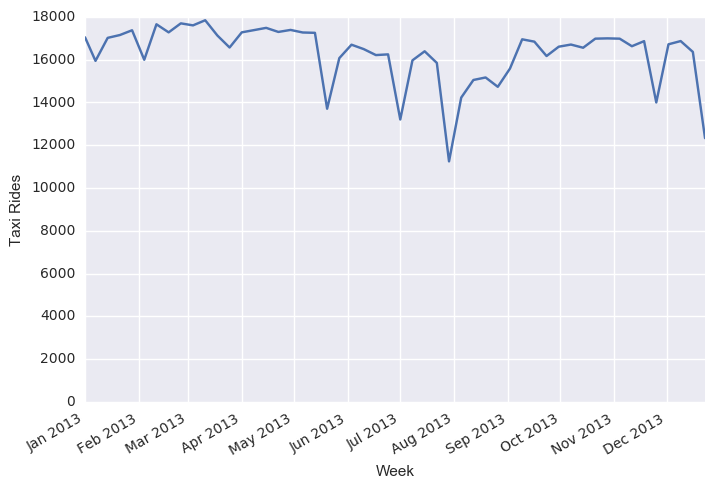

```python
pd.Series(y.values, index=x).plot() # We use the indices of x and the values of y

plt.ylim(0) # Set the lower y value to 0
plt.xlabel('Week') # Label of the x axis
plt.ylabel('Taxi Rides') # Label of the y axis
```

# Joins

- Joins are common operations in databases.
- The idea is to combine several tables together, based on common values shared between the tables.
- In the current example, we have two DataFrames, `data` and `fare`, both with the same number of rows (one row per trip).
- First, from the `fare` `DataFrame`, we will get the average tip obtained by each taxi. Then, we'll inject this information into the `data` `DataFrame`.

```python
fare.head(3)
```

|  | medallion | hack_license | vendor_id | pickup_datetime | payment_type | fare_amount | surcharge | mta_tax | tip_amount | tolls_amount | total_amount |
| --- | --- | --- | --- | --- | --- | --- | --- | --- | --- | --- | --- |
| 0 | 76942C3205E17D7E7FE5A9F709D16434 | 25BA06A87905667AA1FE5990E33F0E2E | VTS | 2013-01-01 00:00:00 | CSH | 5.0 | 0.5 | 0.5 | 0.0 | 0.0 | 6.0 |
| 1 | 517C6B330DBB3F055D007B07512628B3 | 2C19FBEE1A6E05612EFE4C958C14BC7F | VTS | 2013-01-01 00:05:00 | CRD | 13.5 | 0.5 | 0.5 | 2.8 | 0.0 | 17.3 |
| 2 | ED15611F168E41B33619C83D900FE266 | 754AEBD7C80DA17BA1D81D89FB6F4D1D | CMT | 2013-01-01 00:05:52 | CSH | 7.5 | 0.5 | 0.5 | 0.0 | 0.0 | 8.5 |

- To find the average tip per taxi, we will use `groupby()` again.

```python
avg_tip = fare[['medallion', 'tip_amount']].loc[fare.tip_amount > 0].groupby('medallion').mean()
print(len(avg_tip))
avg_tip.head(3)
```

```
13407
```

| medallion | tip_amount |
| --- | --- |
| 00005007A9F30E289E760362F69E4EAD | 1.815854 |
| 000318C2E3E6381580E5C99910A60668 | 2.857222 |
| 000351EDC735C079246435340A54C7C1 | 2.099111 |

- This is not exactly what we want; to combine the fares with the data we'll need to have `medallion` as a column, not as an index.
- To do that we'll use the `reset_index()` method so that although we group by `medallion` we get a numerical index.
- Otherwise `medallion` will become the index.

```python
avg_tip = avg_tip.reset_index()
print(len(avg_tip))
avg_tip.head(3)
```

```
13407
```

|  | medallion | tip_amount |
| --- | --- | --- |
| 0 | 00005007A9F30E289E760362F69E4EAD | 1.815854 |
| 1 | 000318C2E3E6381580E5C99910A60668 | 2.857222 |
| 2 | 000351EDC735C079246435340A54C7C1 | 2.099111 |

- Let's plot a histogram of the tips.

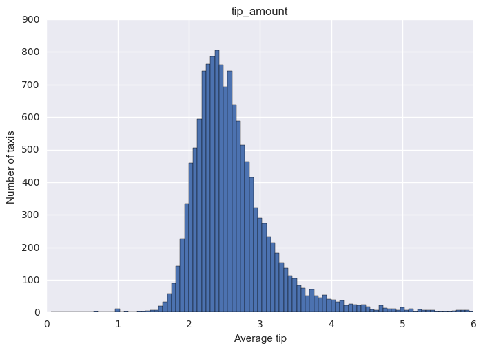

```python
avg_tip.hist(bins=np.linspace(0.0, 6.0, 100))
plt.xlabel('Average tip')
plt.ylabel('Number of taxis')
```

- We'll also get the average distance travelled per taxi.

```python
avg_distance = data[['medallion', 'trip_distance']].loc[data.trip_distance > 0].groupby('medallion').mean().reset_index()
print(len(avg_distance))
avg_distance.head(3)
```

```
13427
```

|  | medallion | trip_distance |
| --- | --- | --- |
| 0 | 00005007A9F30E289E760362F69E4EAD | 2.154118 |
| 1 | 000318C2E3E6381580E5C99910A60668 | 2.553636 |
| 2 | 000351EDC735C079246435340A54C7C1 | 2.257426 |

- To see how a (left) join works, see the following image.

[figure not shown]

- The next step is to join `tip_amount` from `avg_tip` and the `trip_distance` from `avg_distance`.
- The `medallion` column appears in both the `avg_tip` and the `avg_distance` DataFrames.
- By identifying this special field (also called the key) in both data sets, we can associate every row in `avg_tip` to a row in `avg_distance`. This operation is called a join in SQL.
- We do this with the `merge()` method in pandas.

```python
data_merged = pd.merge(avg_distance, avg_tip, how='left', on='medallion')
data_merged.head(3)
```

|  | medallion | trip_distance | tip_amount |
| --- | --- | --- | --- |
| 0 | 00005007A9F30E289E760362F69E4EAD | 2.154118 | 1.815854 |
| 1 | 000318C2E3E6381580E5C99910A60668 | 2.553636 | 2.857222 |
| 2 | 000351EDC735C079246435340A54C7C1 | 2.257426 | 2.099111 |